# Trabajo Práctico Final

| **Universidad** | Universidad Nacional del Oeste |
| --- | --- |
| **Carrera** | Esp. en Ciencia de Datos |
| **Materia** | Exploración y Visualización de Datos (07101) |
| **Profesor** | Mg. Diego Molina |
| **Alumno** | Mg. Ing. Pablo Pandolfo |
| **Fecha** | Junio 2025 |

## Librerias usadas

```r
library(dplyr)
library(ggplot2)
library(ggthemes)
library(hrbrthemes)
library(plotly)
library(tidyr)
library(tidyverse)
library(scales)
library(mice)
```

## Importación de la base de datos

```r
# Borro ambiente de trabajo
rm(list = ls())
# Seteo directorio de trabajo
setwd("/Users/ppando/Materias/data/materias/exploracion-visualizacion/tp")
# Cargo datos del archivo
datos <- read.csv("googleplaystore.csv", sep = ",")
# Verifico cantidad de casos
nrow(datos) > 0
```

```
## [1] TRUE
```

```r
# Muestro los primeros 6 casos
head(datos)
```

|  | App | Category | Rating | Reviews | Size | Installs | Type | Price | Content.Rating | Genres | Last.Updated | Current.Ver | Android.Ver |
| --- | --- | --- | --- | --- | --- | --- | --- | --- | --- | --- | --- | --- | --- |
| 1 | Photo Editor & Candy Camera & Grid & ScrapBook | ART_AND_DESIGN | 4.1 | 159 | 19M | 10,000+ | Free | 0 | Everyone | Art & Design | January 7, 2018 | 1.0.0 | 4.0.3 and up |
| 2 | Coloring book moana | ART_AND_DESIGN | 3.9 | 967 | 14M | 500,000+ | Free | 0 | Everyone | Art & Design;Pretend Play | January 15, 2018 | 2.0.0 | 4.0.3 and up |
| 3 | U Launcher Lite – FREE Live Cool Themes, Hide Apps | ART_AND_DESIGN | 4.7 | 87510 | 8.7M | 5,000,000+ | Free | 0 | Everyone | Art & Design | August 1, 2018 | 1.2.4 | 4.0.3 and up |
| 4 | Sketch - Draw & Paint | ART_AND_DESIGN | 4.5 | 215644 | 25M | 50,000,000+ | Free | 0 | Teen | Art & Design | June 8, 2018 | Varies with device | 4.2 and up |
| 5 | Pixel Draw - Number Art Coloring Book | ART_AND_DESIGN | 4.3 | 967 | 2.8M | 100,000+ | Free | 0 | Everyone | Art & Design;Creativity | June 20, 2018 | 1.1 | 4.4 and up |
| 6 | Paper flowers instructions | ART_AND_DESIGN | 4.4 | 167 | 5.6M | 50,000+ | Free | 0 | Everyone | Art & Design | March 26, 2017 | 1.0 | 2.3 and up |

## 1. Acondicionamiento de la base de datos

### a. Verificar si hay filas duplicadas, y si es así eliminarlas

```r
# Identifico filas duplicadas
duplicados <- duplicated(datos)
# Verifico existencia de filas duplicadas
sum(duplicados) > 0
```

```
## [1] TRUE
```

```r
# Identifico cuales son los duplicados
filter(datos, duplicados)
```

| App | Category | Rating | Reviews | Size | Installs | Type | Price | Content.Rating | Genres | Last.Updated | Current.Ver | Android.Ver |
| --- | --- | --- | --- | --- | --- | --- | --- | --- | --- | --- | --- | --- |
| Quick PDF Scanner + OCR FREE | BUSINESS | 4.2 | 80805 | Varies with device | 5,000,000+ | Free | 0 | Everyone | Business | February 26, 2018 | Varies with device | 4.0.3 and up |
| Box | BUSINESS | 4.2 | 159872 | Varies with device | 10,000,000+ | Free | 0 | Everyone | Business | July 31, 2018 | Varies with device | Varies with device |
| Google My Business | BUSINESS | 4.4 | 70991 | Varies with device | 5,000,000+ | Free | 0 | Everyone | Business | July 24, 2018 | 2.19.0.204537701 | 4.4 and up |
| ZOOM Cloud Meetings | BUSINESS | 4.4 | 31614 | 37M | 10,000,000+ | Free | 0 | Everyone | Business | July 20, 2018 | 4.1.28165.0716 | 4.0 and up |
| join.me - Simple Meetings | BUSINESS | 4.0 | 6989 | Varies with device | 1,000,000+ | Free | 0 | Everyone | Business | July 16, 2018 | 4.3.0.508 | 4.4 and up |
| Box | BUSINESS | 4.2 | 159872 | Varies with device | 10,000,000+ | Free | 0 | Everyone | Business | July 31, 2018 | Varies with device | Varies with device |
| Zenefits | BUSINESS | 4.2 | 296 | 14M | 50,000+ | Free | 0 | Everyone | Business | June 15, 2018 | 3.2.1 | 4.1 and up |
| Google Ads | BUSINESS | 4.3 | 29313 | 20M | 5,000,000+ | Free | 0 | Everyone | Business | July 30, 2018 | 1.12.0 | 4.0.3 and up |
| Google My Business | BUSINESS | 4.4 | 70991 | Varies with device | 5,000,000+ | Free | 0 | Everyone | Business | July 24, 2018 | 2.19.0.204537701 | 4.4 and up |
| Slack | BUSINESS | 4.4 | 51507 | Varies with device | 5,000,000+ | Free | 0 | Everyone | Business | August 2, 2018 | Varies with device | Varies with device |

[output cut: 473 more lines]

```r
# Nuevo data frame con datos únicos
datos <- distinct(datos)
# Verifico sin duplicados
sum(duplicated(datos)) == 0
```

```
## [1] TRUE
```

### b. Detectar datos atípicos, analizarlos, y si es pertinente eliminarlos

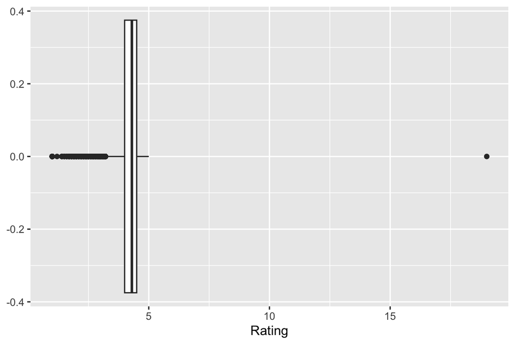

```r
# Detecto valores atípicos de Rating mediante técnica de diagrama de caja
ggplot(datos, aes(Rating)) + geom_boxplot()
```

```r
# Filtro el caso con rating 19, atípico con datos NA
datos <- datos %>% filter(Rating != 19)
# Valido datos sin caso con rating 19
nrow(datos %>% filter(Rating == 19)) == 0
```

```
## [1] TRUE
```

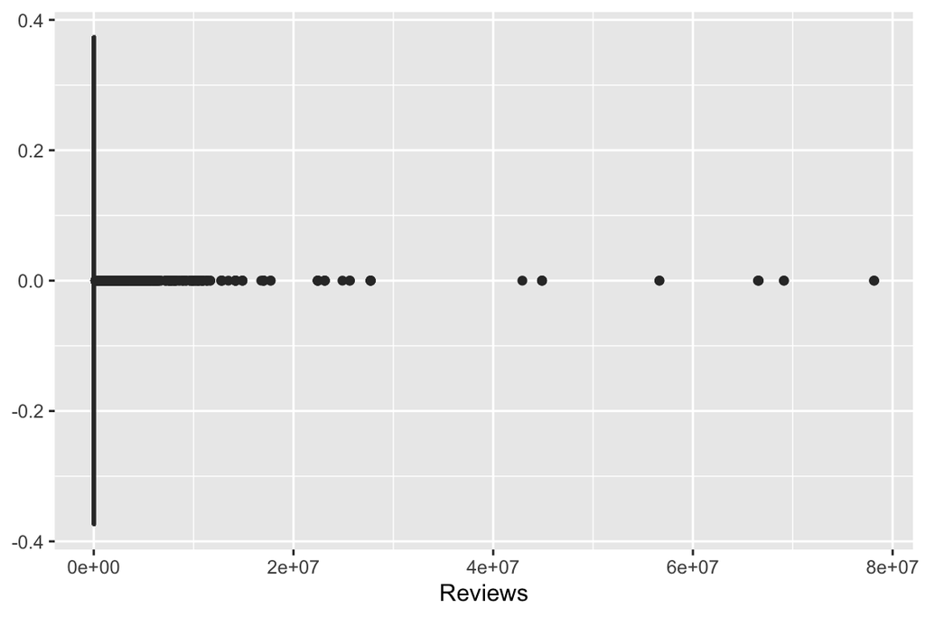

```r
# Convierto variable Reviews a numérico
datos$Reviews = as.numeric(datos$Reviews)
# Detecto valores atípicos de Reviews mediante técnica de diagrama de caja
ggplot(datos, aes(Reviews)) + geom_boxplot()
```

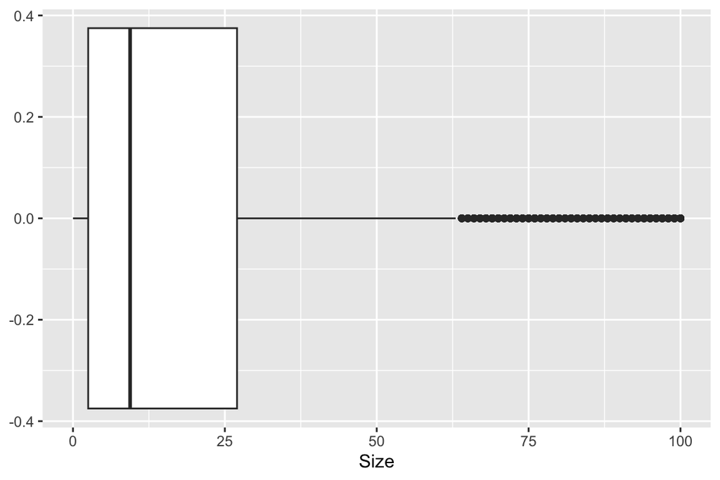

```r
# Saco posfijo "M" y convierto a numérico
datos$Size = ifelse(grepl("M", datos$Size), round(as.numeric(sub("M", "", datos$Size)), 2), datos$Size)
# Saco posfijo "k", convierto a numérico y ajusto valor a Megabyte
datos$Size = ifelse(grepl("k", datos$Size), round(as.numeric(sub("k", "", datos$Size)) / 1024, 2), datos$Size)
# Pongo 0 en lugar de "Varies with device"
datos$Size = as.numeric(sub("Varies with device", "0", datos$Size))
# Detecto valores atípicos de Size mediante técnica de diagrama de caja
ggplot(datos, aes(Size)) + geom_boxplot()
```

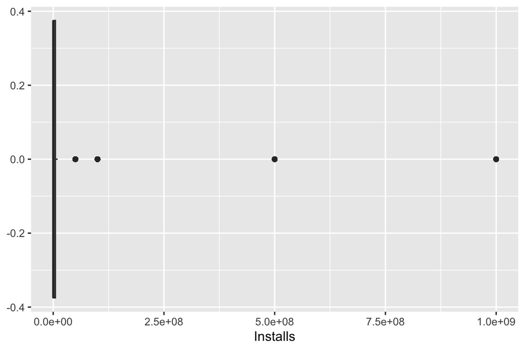

```r
# Saco el sufijo '+' en todas las observaciones de la variable Installs
datos$Installs = sub("[+]", "", datos$Installs)
# Saco el sufijo ',' en todas las observaciones de la variable Installs y convierto a numérico
datos$Installs = as.numeric(gsub("[,]", "", datos$Installs))
# Detecto valores atípicos de Installs mediante técnica de diagrama de caja
ggplot(datos, aes(Installs)) + geom_boxplot()
```

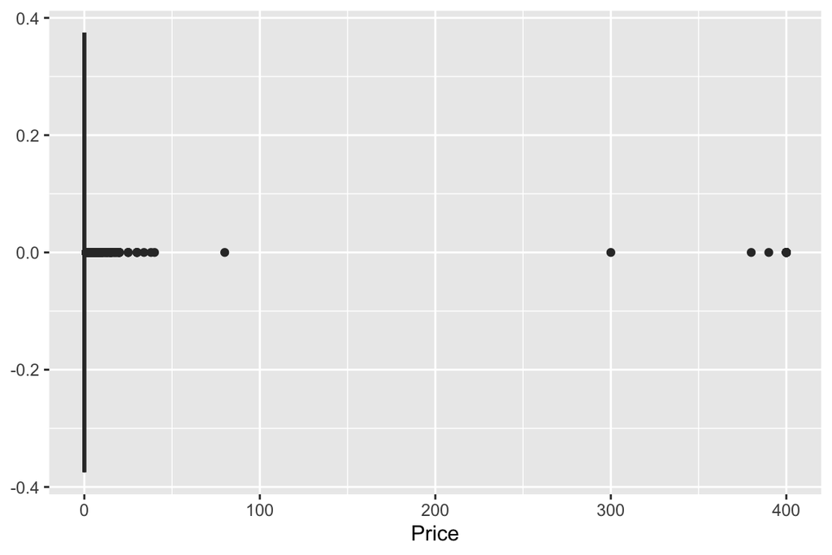

```r
# Saco el prefijo '$' en todas las observaciones de la variable Price y convierto a numérico
datos$Price = as.numeric(sub("[$]", "", datos$Price))
# Detecto valores atípicos de Price mediante técnica de diagrama de caja
ggplot(datos, aes(Price)) + geom_boxplot()
```

**Decido no eliminar mas datos, ya que puedo provocar pérdida de información valiosa**

### c. Verificar los tipos de variables, y si es necesario modificarlos

```r
# Muestro la estructura de los datos
str(datos)
```

```
## 'data.frame':    8892 obs. of  13 variables:
##  $ App           : chr  "Photo Editor & Candy Camera & Grid & ScrapBook" "Coloring book moana" "U Launcher Lite – FREE Live Cool Themes, Hide Apps" "Sketch - Draw & Paint" ...
##  $ Category      : chr  "ART_AND_DESIGN" "ART_AND_DESIGN" "ART_AND_DESIGN" "ART_AND_DESIGN" ...
##  $ Rating        : num  4.1 3.9 4.7 4.5 4.3 4.4 3.8 4.1 4.4 4.7 ...
##  $ Reviews       : num  159 967 87510 215644 967 ...
##  $ Size          : num  19 14 8.7 25 2.8 5.6 19 29 33 3.1 ...
##  $ Installs      : num  1e+04 5e+05 5e+06 5e+07 1e+05 5e+04 5e+04 1e+06 1e+06 1e+04 ...
##  $ Type          : chr  "Free" "Free" "Free" "Free" ...
##  $ Price         : num  0 0 0 0 0 0 0 0 0 0 ...
##  $ Content.Rating: chr  "Everyone" "Everyone" "Everyone" "Teen" ...
##  $ Genres        : chr  "Art & Design" "Art & Design;Pretend Play" "Art & Design" "Art & Design" ...
##  $ Last.Updated  : chr  "January 7, 2018" "January 15, 2018" "August 1, 2018" "June 8, 2018" ...
##  $ Current.Ver   : chr  "1.0.0" "2.0.0" "1.2.4" "Varies with device" ...
##  $ Android.Ver   : chr  "4.0.3 and up" "4.0.3 and up" "4.0.3 and up" "4.2 and up" ...
```

- **cualitativas (categóricas)** = {App, Category, Types, Content.Rating, Genres, Last.Updated, Current.Ver, Android.Ver}
- **cuantitativas (numéricas)** = {Rating, Reviews, Size, Installs, Price}

### d. Agrupar las categorías que consideres necesarias

```r
# Declaro a determinadas variables cualitativas como factor, para poder reconocer categorias
datos$Category <- as.factor(datos$Category)
datos$Type <- as.factor(datos$Type)
datos$Content.Rating <- as.factor(datos$Content.Rating)
datos$Genres <- as.factor(datos$Genres)
```

## 2. Análisis descriptivo

### a. Calcular el promedio, desvío, mediana, y cuartiles para las variables numéricas (cuantitativas) por categoría. Nota: si la variable tiene un rango muy amplio separar por grupo y realizar estos cálculos dentro de cada grupo

#### Promedio (mean)

```r
# Calculo promedios
datos %>%
  group_by(Category) %>%
  select(Rating, Reviews, Size, Installs, Price) %>%
  summarize(
    promedio_rating = mean(Rating, na.rm = TRUE),
    promedio_reviews = mean(Reviews, na.rm = TRUE),
    promedio_size = mean(Size, na.rm = TRUE),
    promedio_installs = mean(Installs, na.rm = TRUE),
    promedio_precio = mean(Price, na.rm = TRUE)
)
```

| Category | promedio_rating | promedio_reviews | promedio_size | promedio_installs | promedio_precio |
| --- | --- | --- | --- | --- | --- |
| ART_AND_DESIGN | 4.358065 | 27651.161 | 12.148387 | 2003759.7 | 0.096290323 |
| AUTO_AND_VEHICLES | 4.190411 | 15940.137 | 18.590411 | 727805.5 | 0.027260274 |
| BEAUTY | 4.278571 | 9407.929 | 13.666667 | 640861.9 | 0.000000000 |
| BOOKS_AND_REFERENCE | 4.347458 | 123575.243 | 11.494802 | 10826506.5 | 0.134915254 |
| BUSINESS | 4.102593 | 45769.278 | 11.675296 | 3198215.3 | 0.238555556 |
| COMICS | 4.155172 | 58309.397 | 11.115862 | 966139.7 | 0.000000000 |
| COMMUNICATION | 4.151466 | 1958544.270 | 8.278436 | 78671796.5 | 0.184657980 |
| DATING | 3.971698 | 34875.245 | 15.605660 | 1298883.1 | 0.144402516 |
| EDUCATION | 4.375969 | 179571.504 | 14.754651 | 4138387.6 | 0.139224806 |
| ENTERTAINMENT | 4.136036 | 428565.009 | 13.664865 | 22123063.1 | 0.071891892 |

[output cut: 23 more lines]

#### Desvío (sd)

```r
# Calculo desvios
datos %>%
  group_by(Category) %>%
  select(Rating, Reviews, Size, Installs, Price) %>%
  summarize(
    desvio_rating = sd(Rating, na.rm = TRUE),
    desvio_reviews = sd(Reviews, na.rm = TRUE),
    desvio_size = sd(Size, na.rm = TRUE),
    desvio_installs = sd(Installs, na.rm = TRUE),
    desvio_precio = sd(Price, na.rm = TRUE)
)
```

| Category | desvio_rating | desvio_reviews | desvio_size | desvio_installs | desvio_precio |
| --- | --- | --- | --- | --- | --- |
| ART_AND_DESIGN | 0.3582967 | 70759.757 | 9.976016 | 6813394.4 | 0.43050574 |
| AUTO_AND_VEHICLES | 0.5436922 | 46494.623 | 20.926884 | 1866462.0 | 0.23291188 |
| BEAUTY | 0.3626029 | 21071.335 | 13.995220 | 1691596.9 | 0.00000000 |
| BOOKS_AND_REFERENCE | 0.4298609 | 399364.281 | 15.960272 | 76940898.4 | 0.67608341 |
| BUSINESS | 0.6522144 | 181509.153 | 13.638344 | 12793158.0 | 1.57063615 |
| COMICS | 0.5377577 | 198995.154 | 11.179700 | 2132610.3 | 0.00000000 |
| COMMUNICATION | 0.4383825 | 7574686.904 | 12.753505 | 223082587.0 | 0.76347126 |
| DATING | 0.6210579 | 87350.931 | 14.965205 | 2800956.5 | 0.94542509 |
| EDUCATION | 0.2603409 | 790477.790 | 19.175716 | 12574521.3 | 0.79618192 |
| ENTERTAINMENT | 0.3210191 | 1206700.286 | 17.855494 | 97306317.7 | 0.54992977 |

[output cut: 23 more lines]

#### Mediana (median)

```r
# Calculo medianas
datos %>%
  group_by(Category) %>%
  select(Rating, Reviews, Size, Installs, Price) %>%
  summarize(
    mediana_rating = median(Rating, na.rm = TRUE),
    mediana_reviews = median(Reviews, na.rm = TRUE),
    mediana_size = median(Size, na.rm = TRUE),
    mediana_installs = median(Installs, na.rm = TRUE),
    mediana_precio = median(Price, na.rm = TRUE)
)
```

| Category | mediana_rating | mediana_reviews | mediana_size | mediana_installs | mediana_precio |
| --- | --- | --- | --- | --- | --- |
| ART_AND_DESIGN | 4.40 | 622.5 | 8.95 | 100000 | 0 |
| AUTO_AND_VEHICLES | 4.30 | 737.0 | 9.00 | 100000 | 0 |
| BEAUTY | 4.30 | 750.5 | 9.10 | 100000 | 0 |
| BOOKS_AND_REFERENCE | 4.50 | 1435.0 | 5.40 | 100000 | 0 |
| BUSINESS | 4.25 | 213.0 | 6.95 | 10000 | 0 |
| COMICS | 4.40 | 1844.5 | 7.10 | 100000 | 0 |
| COMMUNICATION | 4.30 | 34443.0 | 2.80 | 1000000 | 0 |
| DATING | 4.10 | 1939.0 | 11.00 | 100000 | 0 |
| EDUCATION | 4.40 | 18372.0 | 7.00 | 1000000 | 0 |
| ENTERTAINMENT | 4.20 | 44550.0 | 8.50 | 5000000 | 0 |

[output cut: 23 more lines]

#### Quantiles (quantile)

```r
# Calculo quantiles
datos %>%
  group_by(Category) %>%
  select(Rating, Reviews, Size, Installs, Price) %>%
  summarize(
    quantiles_rating = quantile(Rating, probs = c(0.25, 0.50, 0.75), na.rm = TRUE),
    quantiles_reviews = quantile(Reviews, probs = c(0.25, 0.50, 0.75), na.rm = TRUE),
    quantiles_size = quantile(Size, probs = c(0.25, 0.50, 0.75), na.rm = TRUE),
    quantiles_installs = quantile(Installs, probs = c(0.25, 0.50, 0.75), na.rm = TRUE),
    quantiles_precio = quantile(Price, probs = c(0.25, 0.50, 0.75), na.rm = TRUE)
)
```

| Category | quantiles_rating | quantiles_reviews | quantiles_size | quantiles_installs | quantiles_precio |
| --- | --- | --- | --- | --- | --- |
| ART_AND_DESIGN | 4.100 | 158.25 | 4.2500 | 1.0e+04 | 0 |
| ART_AND_DESIGN | 4.400 | 622.50 | 8.9500 | 1.0e+05 | 0 |
| ART_AND_DESIGN | 4.700 | 7212.75 | 19.0000 | 5.0e+05 | 0 |
| AUTO_AND_VEHICLES | 4.000 | 107.00 | 2.9000 | 1.0e+04 | 0 |
| AUTO_AND_VEHICLES | 4.300 | 737.00 | 9.0000 | 1.0e+05 | 0 |
| AUTO_AND_VEHICLES | 4.600 | 5414.00 | 32.0000 | 5.0e+05 | 0 |
| BEAUTY | 4.000 | 68.00 | 3.1250 | 1.0e+04 | 0 |
| BEAUTY | 4.300 | 750.50 | 9.1000 | 1.0e+05 | 0 |
| BEAUTY | 4.575 | 4365.25 | 21.0000 | 5.0e+05 | 0 |
| BOOKS_AND_REFERENCE | 4.100 | 82.00 | 2.1000 | 5.0e+03 | 0 |

[output cut: 89 more lines]

### b. Armar una función, que como argumento de entrada reciba la base datos, y como salida entregue una lista, solo para el grupo de jóvenes (Teen), en donde cada nivel sea para cada categoría. La función debe entregar lo siguiente: nombre de la categoría, un dataframe con las columnas App y Reviews, mínimo, máximo y promedio de Reviews

```r
# Declaro e implemento la función: bd -> list
funcion <- function(bd) {
  lista_externa <- list()
  categorias <- distinct(bd %>% select(Category))
  for (cat in categorias$Category) {
    df <- bd %>% filter(Content.Rating == 'Teen') %>% filter(Category == cat) %>% select(App, Reviews)
    lista_interna <- list(c(cat, min(df$Reviews), max(df$Reviews), mean(df$Reviews)), df)
    lista_externa <- append(lista_externa, lista_interna)
  }
  return (lista_externa)
}

# Invoco a la función y muestro la lista resultado
print(funcion(datos))
```

```
## [[1]]
## [1] "ART_AND_DESIGN" "353"            "215644"         "86942"
##
## [[2]]
##                              App Reviews
## 1          Sketch - Draw & Paint  215644
## 2 Tattoo Name On My Photo Editor   44829
## 3                I Creative Idea     353
##
## [[3]]
## [1] "AUTO_AND_VEHICLES" "271920"            "271920"            "271920"
##
## [[4]]
##                                             App Reviews
## 1 Android Auto - Maps, Media, Messaging & Voice  271920
```

[output cut: 1207 more lines]

## 3. Análisis exploratorio y visualización

### a. Comparar por año el total de actualizaciones que tuvo cada categoría

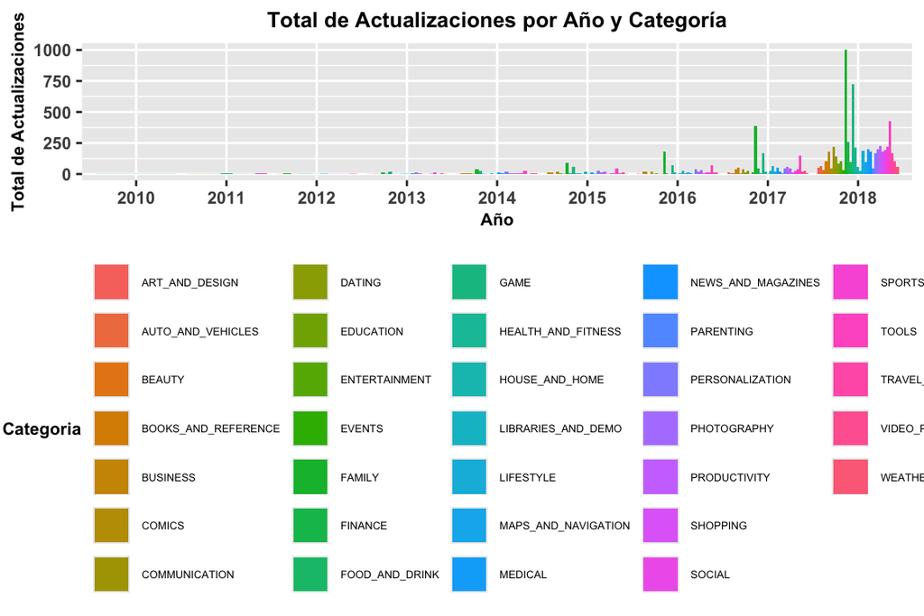

```r
# Divido la fecha, extraigo el año de cada caso y creo una variable Year
datos$Year <- sapply(strsplit(datos$Last.Updated, ", "), function(x) x[2])

# Cuento actualizaciones por año y categoría
resumen <- datos %>%
  group_by(Year, Category) %>%
  summarise(Total_Actualizaciones = n(), .groups = "drop")

ggplot(resumen, aes(x = Year, y = Total_Actualizaciones, fill = Category)) +
  geom_bar(stat = "identity", position = "dodge") +
  labs(title = "Total de Actualizaciones por Año y Categoría",
       x = "Año",
       y = "Total de Actualizaciones",
       fill = "Categoria") +
  theme(plot.title = element_text(size = 10, face = "bold", hjust = 0.5),
        legend.position = "bottom",
        legend.title = element_text(size = 8, face = "bold"),
        legend.text = element_text(size = 5),
        axis.text = element_text(size = 8, face = "bold"),
        axis.title = element_text(size = 8, face = "bold"))
```

En 2018, hubo un aumento significativo en las actualizaciones de aplicaciones debido a varios factores clave como: **avances en los sistemas operativos, mayor enfoque en seguridad, competencia y retención de usuarios** y **nuevas funcionalidades**, ya que plataformas como Instagram introdujeron características innovadoras que impulsó una ola de actualizaciones en aplicaciones similares.Este aumento en la periodicidad de actualizaciones reflejó la evolución del mercado de aplicaciones y la necesidad de mantenerse relevante en un entorno digital en constante cambio.

### b. ¿Cuál fue la aplicación más cara de cada categoría?

```r
resumen <- datos %>%
  group_by(Category) %>%
  summarise(
    app_mas_cara = App[which.max(Price)],
    precio_mas_caro = max(Price, na.rm = TRUE),
    .groups = 'drop')
resumen
```

| Category | app_mas_cara | precio_mas_caro |
| --- | --- | --- |
| ART_AND_DESIGN | X Launcher Pro: PhoneX Theme, OS11 Control Center | 1.99 |
| AUTO_AND_VEHICLES | Ulysse Speedometer Pro | 1.99 |
| BEAUTY | Hush - Beauty for Everyone | 0.00 |
| BOOKS_AND_REFERENCE | Officiel du SCRABBLE LAROUSSE | 4.60 |
| BUSINESS | SkyTest BU/GU Lite | 17.99 |
| COMICS | LINE WEBTOON - Free Comics | 0.00 |
| COMMUNICATION | K-@ Mail Pro - Email App | 4.99 |
| DATING | AMBW Dating App: Asian Men Black Women Interracial | 7.99 |
| EDUCATION | Fuzzy Numbers: Pre-K Number Foundation | 5.99 |
| ENTERTAINMENT | My Talking Pet | 4.99 |

[output cut: 23 more lines]

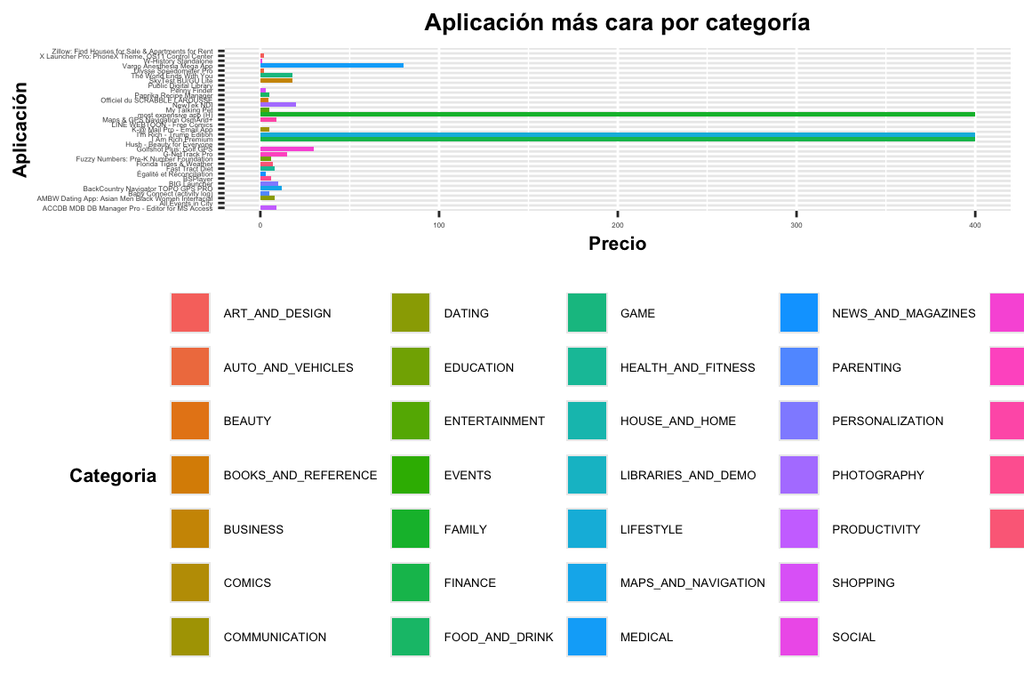

```r
ggplot(resumen, aes(x = precio_mas_caro, y = app_mas_cara, fill = Category)) +
  geom_col() +
  labs(title = "Aplicación más cara por categoría",
       y = "Aplicación",
       x = "Precio",
       fill = "Categoria") +
  theme(plot.title = element_text(size = 10, face = "bold", hjust = 0.5),
        legend.position = "bottom",
        legend.title = element_text(size = 8, face = "bold"),
        legend.text = element_text(size = 5),
        axis.text = element_text(size = 3),
        axis.title = element_text(size = 8, face = "bold"))
```

### c. Analizar y comparar la distribución del rating entre las aplicaciones pagas y gratuitas

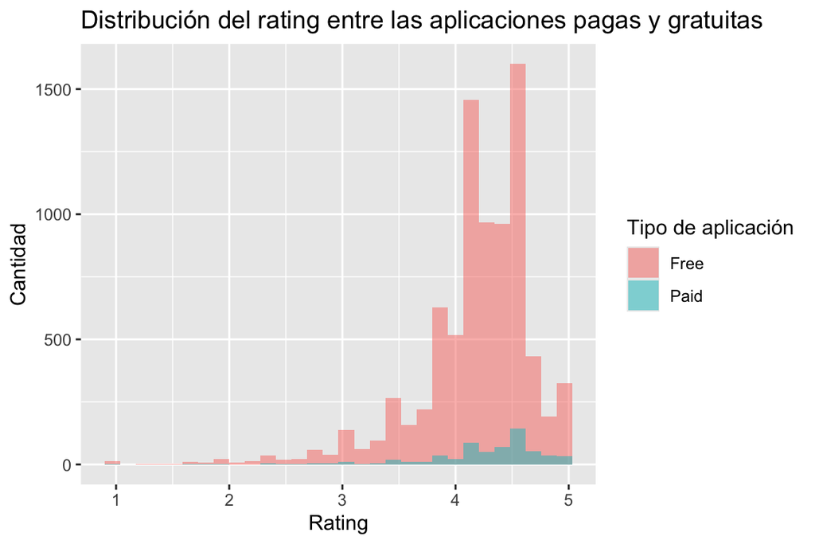

```r
ggplot(datos, aes(x = Rating, fill = Type)) +
  geom_histogram(alpha = 0.5, position = "identity") +
  labs(title = "Distribución del rating entre las aplicaciones pagas y gratuitas",
       y = "Cantidad",
       x = "Rating",
       fill = "Tipo de aplicación")
```

Observo lo siguiente:

- **Aplicaciones gratuitas** suelen tener muchas más descargas, ya que no requieren un compromiso financiero inmediato.
- **Aplicaciones pagas** tienen un volumen de descarga más reducido pero pueden atraer usuarios que buscan funcionalidades específicas o experiencias sin anuncios.

### d. Realizar una visualización que muestre las diferencias en las categorías referidas salud y las referidas al deporte, con respecto al tamaño de la aplicación, diferenciando entre aplicaciones gratuitas y pagas

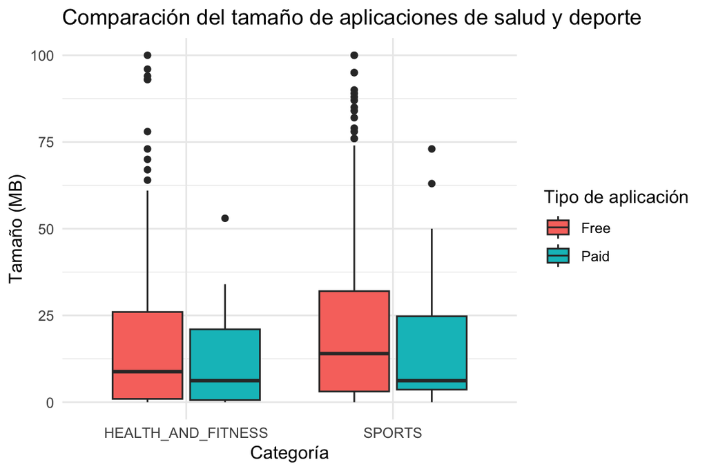

```r
# Filtro categorias relacionadas con salud y deporte
filtrado <- datos %>% filter(Category %in% c("HEALTH_AND_FITNESS","SPORTS"))

ggplot(filtrado, aes(x = Category, y = Size, fill = Type)) +
  geom_boxplot() +
  theme_minimal() +
  labs(title = "Comparación del tamaño de aplicaciones de salud y deporte",
       x = "Categoría",
       y = "Tamaño (MB)",
       fill = "Tipo de aplicación")
```

### e. Realizar un gráfico que muestre la evolución de la cantidad de actualizaciones por mes para el año 2018, comparando las categorías sobre salud, educación y entretenimiento

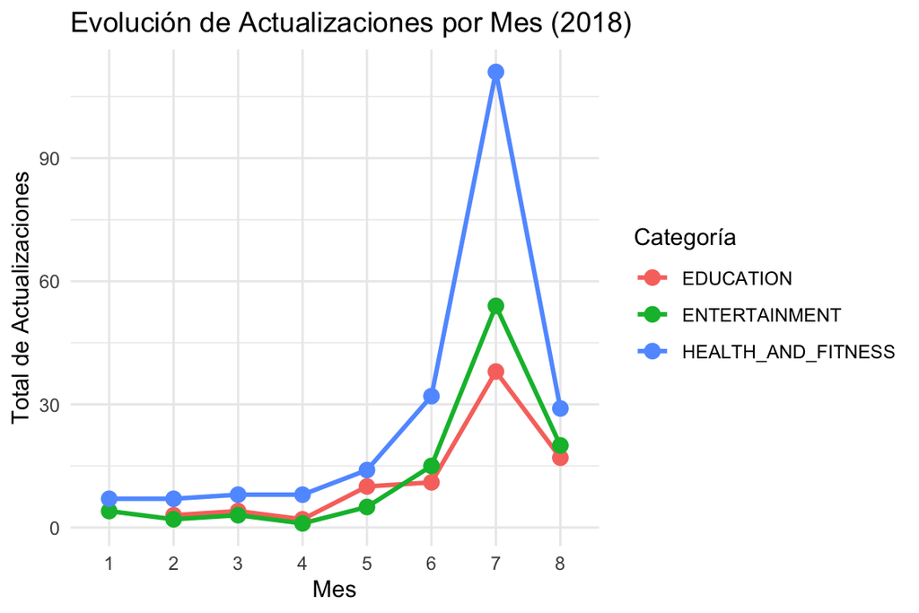

```r
meses <- c("January", "February", "March", "April", "May", "June", "July", "August", "September", "October", "November", "December")

 # Divido la fecha, extraigo el mes de cada caso y creo una variable Month
datos$Month <- sapply(strsplit(datos$Last.Updated, " "), function(x) x[1])

# Asigno a cada mes su número correspondiente y creo una variable NMonth
datos$NMonth <- factor(match(datos$Month, meses), levels = 1:12)

filtrado <- datos %>%
  filter(Year == "2018" & Category %in% c("HEALTH_AND_FITNESS","EDUCATION","ENTERTAINMENT")) %>%
  group_by(Month, NMonth, Category) %>%
  summarise(Total_Actualizaciones = n(), .groups = "drop") %>%
  arrange(NMonth)

ggplot(filtrado, aes(x = NMonth, y = Total_Actualizaciones, group = Category, color = Category)) +
  geom_line(size = 1) +
  geom_point(size = 3) +
  theme_minimal() +
  labs(title = "Evolución de Actualizaciones por Mes (2018)",
       x = "Mes",
       y = "Total de Actualizaciones",
       color = "Categoría")
```

### f. Mediante diagramas de boxplots comparar los precios de las aplicaciones referidas a la familia, al juego, y a la salud

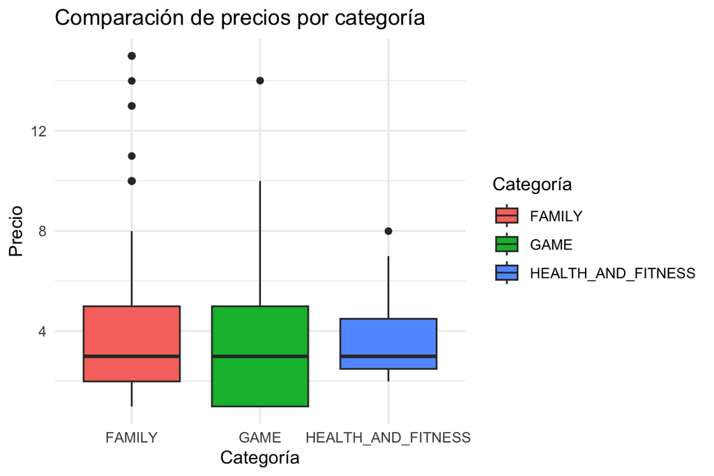

```r
filtrado <- datos %>% filter(Category %in% c("FAMILY", "GAME", "HEALTH_AND_FITNESS") & between(Price, 0.01, 15))

# Visualizo la dispersión, mediana y posibles valores atípicos de los precios en cada categoría
ggplot(filtrado, aes(x = Category, y = Price, fill = Category)) +
  geom_boxplot() +
  theme_minimal() +
  labs(title = "Comparación de precios por categoría",
       x = "Categoría",
       y = "Precio",
       fill = "Categoría")
```

Observo lo siguiente:

- Las tres categoria tienen la misma mediana; por los que se concluye que los casos estan separados de la misma manera.
- En la categoria GAME se observa mayor dispersion de precios que en las otras categorias.

### g. Dentro del grupo adolecente (Teen) realizar una comparación entre las categorías referidas al entretenimiento y el juego con respecto a las que no lo son

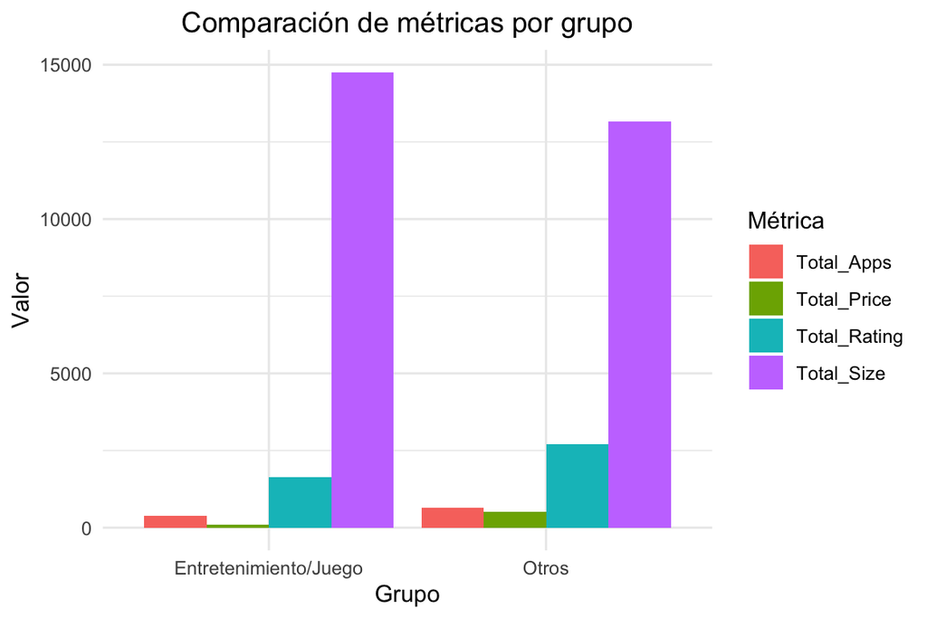

```r
# Filtro aplicaciones con Content.Rating "Teen" y creo un indicador para diferenciar grupos
filtrado <- datos %>%
  filter(Content.Rating == "Teen") %>%
  mutate(Grupo = ifelse(Category %in% c("ENTERTAINMENT", "GAME"), "Entretenimiento/Juego", "Otros")) %>%
  group_by(Grupo) %>%
  summarise(
    Total_Apps = n(),
    Total_Rating = sum(Rating),
    Total_Size = sum(Size),
    Total_Price = sum(Price)
  ) %>%
  pivot_longer(cols = c(Total_Apps, Total_Rating, Total_Size, Total_Price),
               names_to = "Métrica",
               values_to = "Valor")

ggplot(filtrado, aes(x = Grupo, y = Valor, fill = Métrica)) +
  geom_bar(stat = "identity", position = "dodge") +
  theme_minimal() +
  labs(title = "Comparación de métricas por grupo",
       x = "Grupo", y = "Valor") +
  theme(plot.title = element_text(hjust = 0.5))
```

Observo que el Grupo **Otros** la métrica **Total_Apps** tiene una cantidad mayor respecto de las aplicaciones de **Entretenimiento/Juego**, puedo sugerir que hay una diversidad más amplia en las necesidades de los adolescentes.

También se puede observar que la categoría **Entretenimiento/Juego** tiene aplicaciones de mayor tamaño, porque vemos que son menos aplicaciones y el valor de la métrica Total_Size es mayor.

### h. ¿Hay relación entre el tamaño y el precio? Realizar el análisis de manera global y por categoría (elegir 4)

```r
# Calculo la correlación entre Size y Price para ver si existe una relación estadística entre ambos valores
correlacion_global <- cor(datos$Size, datos$Price, use = "complete.obs")
print(correlacion_global)
```

```
## [1] -0.0171171
```

```r
# -0.0171171
# Como el valor está muy próximo a 0, significa que no hay una relación lineal clara entre Size y Price; es decir, el tamaño de la app no parece influir en su precio de forma evidente


# Filtro datos por las categorías seleccionadas
filtrado <- datos %>% filter(Category %in% c("GAME", "BUSINESS", "TOOLS", "LIFESTYLE"))

# Calculo correlaciones por categoría
correlaciones_por_categoria <- filtrado %>%
  group_by(Category) %>%
  summarise(
    Correlación_Size_Price = cor(Size, Price, use = "complete.obs")
  )

print(correlaciones_por_categoria)
```

```
## # A tibble: 4 × 2
##   Category  Correlación_Size_Price
##   <fct>                      <dbl>
## 1 BUSINESS                -0.00192
## 2 GAME                    -0.0846
## 3 LIFESTYLE               -0.0449
## 4 TOOLS                   -0.0901
```

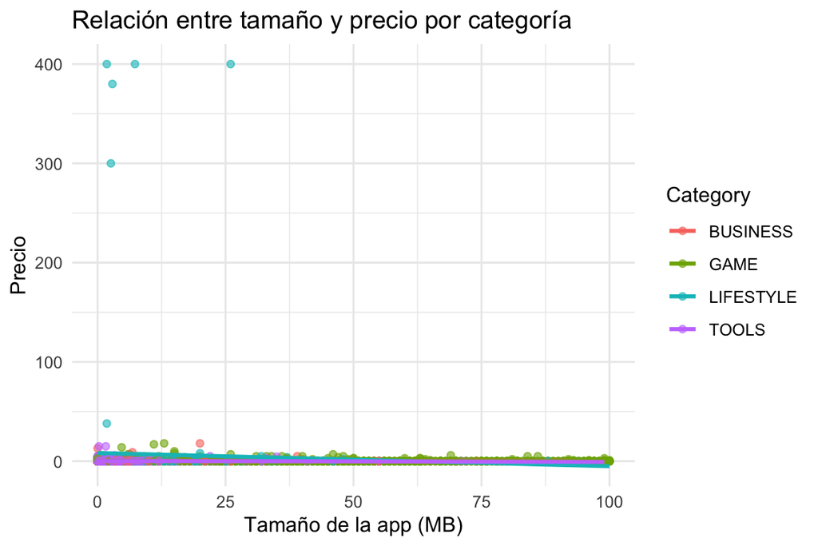

```r
ggplot(filtrado, aes(x = Size, y = Price, color = Category)) +
  geom_point(alpha = 0.6) +
  geom_smooth(method = "lm", se = FALSE) +
  theme_minimal() +
  labs(title = "Relación entre tamaño y precio por categoría",
       x = "Tamaño de la app (MB)", y = "Precio")
```

- Observo que no hay relación clara entre el tamaño y precio de la aplicación, el precio podría depender de otros factores (como funcionalidad, demanda, etc.)